# ST758 2014 HW5

Hua Zhou

Oct 12, 2014

# Q1

Both $\boldsymbol{R}_1$ and $\boldsymbol{R}_2$ are the Cholesky factor of the pd matrix $\boldsymbol{X}^T \boldsymbol{X}$, which we have shown (by induction) to be unique. Therefore $\boldsymbol{R}_1 = \boldsymbol{R}_2$ and $\boldsymbol{Q}_1 = \boldsymbol{X} \boldsymbol{R}_1^{-1} = \boldsymbol{X} \boldsymbol{R}_2^{-1} = \boldsymbol{Q}_2$.

# Q2

Let $\boldsymbol{X} = \boldsymbol{U} \boldsymbol{\Sigma} \boldsymbol{V}^T$ be the thin SVD of design matrix. Then the ridge solution at $\lambda$ is  
$\begin{eqnarray*} \hat{\boldsymbol{\beta}} (\lambda) &=& (\boldsymbol{V} \boldsymbol{\Sigma}^2 \boldsymbol{V}^T + \lambda \boldsymbol{I}_p)^{-1} \boldsymbol{V} \boldsymbol{\Sigma} \boldsymbol{U} \boldsymbol{y} \\ &=& [\boldsymbol{V} (\boldsymbol{\Sigma}^2 + \lambda \boldsymbol{I}_p) \boldsymbol{V}^T]^{-1} \boldsymbol{V} \boldsymbol{\Sigma} \boldsymbol{U}^T \boldsymbol{y} \\ &=& \boldsymbol{V} (\boldsymbol{\Sigma}^2 + \lambda \boldsymbol{I}_p)^{-1} \boldsymbol{\Sigma} \boldsymbol{U}^T \boldsymbol{y} \\ &=& \sum_{i=1}^r \frac{\sigma_i \boldsymbol{u}_i^T \boldsymbol{y}}{\sigma_i^2 + \lambda} \boldsymbol{v}_i \end{eqnarray*}$  
with squared $\ell_2$ norm  
$\|\hat{\boldsymbol{\beta}} (\lambda)\|_2^2 = \sum_{i=1}^r \left( \frac{\sigma_i \boldsymbol{u}_i^T \boldsymbol{y}}{\sigma_i^2 + \lambda} \right)^2.$  
Each summand is decreasing in $\lambda$, so is $\|\hat{\boldsymbol{\beta}} (\lambda)\|_2$.

The fitted values at $\lambda$ is  
$\begin{eqnarray*} \hat{\boldsymbol{y}} (\lambda) &=& \boldsymbol{X} \hat{\boldsymbol{\beta}} (\lambda) \\ &=& \boldsymbol{U} \boldsymbol{\Sigma} (\boldsymbol{\Sigma}^2 + \lambda \boldsymbol{I}_p)^{-1} \boldsymbol{\Sigma} \boldsymbol{U}^T \boldsymbol{y} \\ &=& \sum_{i=1}^r \frac{\sigma_i^2 \boldsymbol{u}_i^T \boldsymbol{y}}{\sigma_i^2 + \lambda} \boldsymbol{u}_i \end{eqnarray*}$ with squared $\ell_2$ norm $\|\hat{\boldsymbol{y}} (\lambda)\|_2^2 = \sum_{i=1}^r \left( \frac{\sigma_i^2 \boldsymbol{u}_i^T \boldsymbol{y}}{\sigma_i^2 + \lambda} \right)^2.$ Again each summand is decreasing in $\lambda$, so is $\|\hat{\boldsymbol{y}} (\lambda)\|_2$.

The residual vector at $\lambda$ is $\begin{eqnarray*} \hat{\boldsymbol{r}} (\lambda) &=& \boldsymbol{y} - \boldsymbol{X} \hat{\boldsymbol{\beta}} (\lambda) \\ &=& \left[ \boldsymbol{I}_n - \boldsymbol{U} \boldsymbol{\Sigma} (\boldsymbol{\Sigma}^2 + \lambda \boldsymbol{I}_p)^{-1} \boldsymbol{\Sigma} \boldsymbol{U}^T \right] \boldsymbol{y} \\ &=& \boldsymbol{U} [\boldsymbol{I}_n - \boldsymbol{\Sigma} (\boldsymbol{\Sigma}^2 + \lambda \boldsymbol{I}_p)^{-1} \boldsymbol{\Sigma}] \boldsymbol{U}^T \boldsymbol{y} \\ &=& \sum_{i=1}^r \frac{\boldsymbol{u}_i^T \boldsymbol{y}}{\sigma_i^2/\lambda + 1} \boldsymbol{u}_i \end{eqnarray*}$ with squared $\ell_2$ norm  
$\|\hat{\boldsymbol{r}} (\lambda)\|_2^2 = \sum_{i=1}^r \left( \frac{\boldsymbol{u}_i^T \boldsymbol{y}}{\sigma_i^2/\lambda + 1} \right)^2.$ We see each summand here is increasing in $\lambda$, so is $\|\hat{\boldsymbol{r}} (\lambda)\|_2$.

Here is a simple function for ridge regression

```r
#' Ridge regression
#'
#' \code{ridge.svd} implements the ridge regression using SVD
#'
#' @param y a length n response vector
#' @param X an n-by-p predictor matrix
#' @param lambda a vector of nonnegative tuning parameter values
#' @return a list that contains:
#'  betahat, ridge solution at each lambda values
#'  yhat, fitted values at each lambda values
#'  resid, residual vector at each lambda values
#' @seealso
ridge.svd <- function(y, X, lambda) {

  # check dimension
  if (dim(X)[1] != length(y))
    stop("X and y should have same number of obs.")

  # check nonnegativity of lambda
  if (any(lambda < 0))
    stop("tuning parameter lambda should be nonnegative")

  # pre-compute SVD of X and t(U) %*% y
  xsvd <- svd(X)
  uty <- as.vector(crossprod(xsvd$u, y))

  # M contains entries sigma_i / (sigma_i^2 + \lambda_j)
  M <- outer(xsvd$d, lambda, function(a, b) a / (a^2 + b))
  # ridge solution at all lambda
  betahat <- xsvd$v %*% (M * uty)
  # fitted values
  yhat <- xsvd$u %*% (M * (uty * xsvd$d))
  # residuals
  resid <- y - yhat

  # output
  list(betahat = betahat, yhat = yhat, resid = resid)

  }
```

Let’s re-do the Longley data using the new `ridge.svd` function.

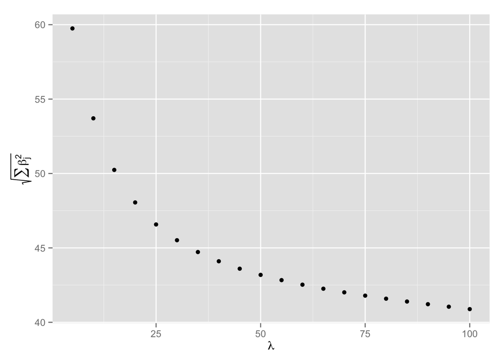

```r
library(ggplot2)
# read in Longley data and set up X and y
all <-
  read.table("http://hua-zhou.github.io/teaching/st758-2014fall/longley.dat",
             col.names = c("employed", "GNPdef", "GNP", "unemployed", "armed",
                           "pop", "year"))
X <- cbind(1, as.matrix(all[, 2:7]))
colnames(X)[1] <- "intercept"
y <- as.vector(all[, 1])
# ridge regression
lambda <- seq(5, 100, 5)
result <- ridge.svd(y, X, lambda)
# compute and plot l2 norms of ridge solutions, fitted values, and residuals
betahatl2 <- sqrt(colSums(result$betahat * result$betahat))
qplot(lambda, betahatl2, xlab = expression(lambda),
      ylab = expression(sqrt(sum(beta[j]^2))))
```

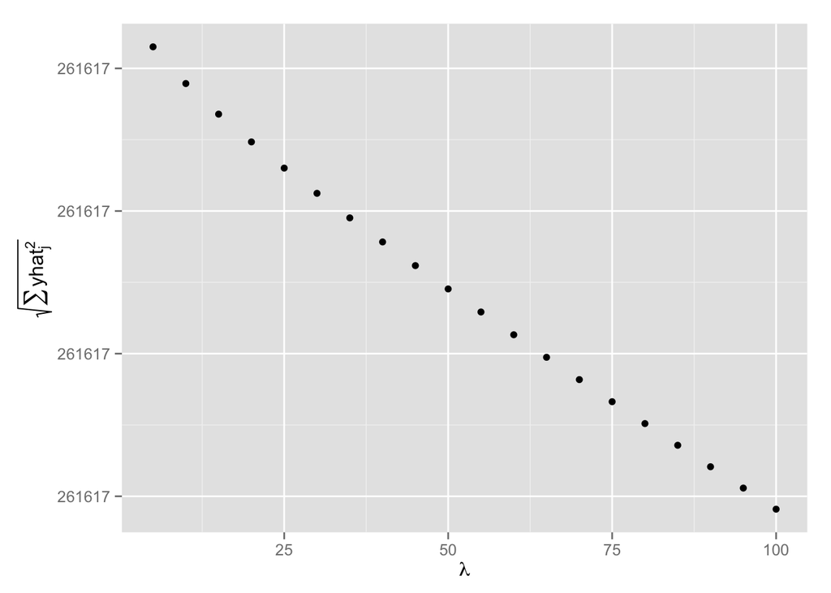

```r
yhatl2 <- sqrt(colSums(result$yhat * result$yhat))
qplot(lambda, yhatl2, xlab = expression(lambda),
      ylab = expression(sqrt(sum(yhat[j]^2))))
```

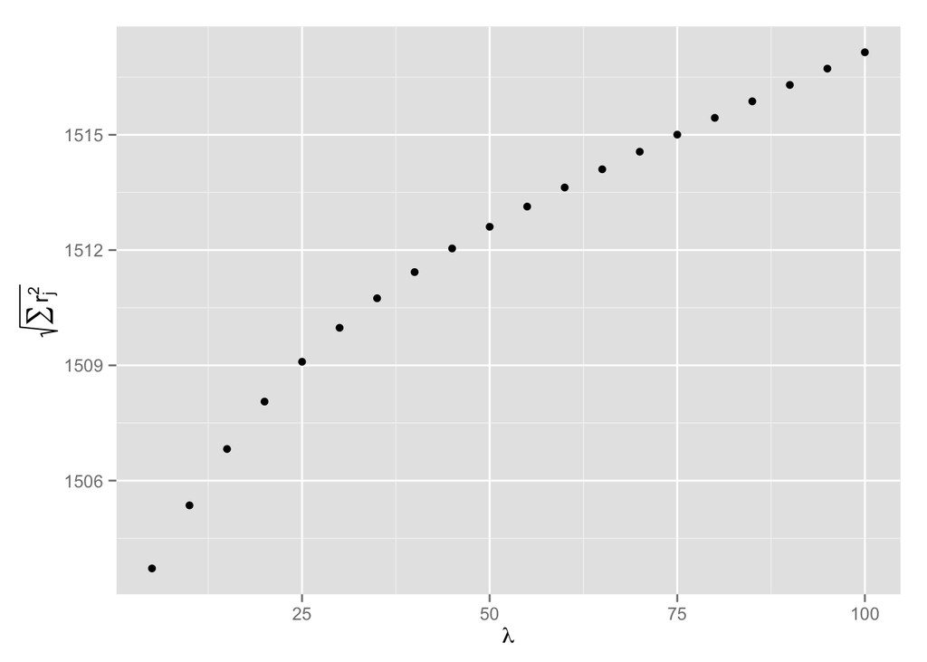

```r
residl2 <- sqrt(colSums(result$resid * result$resid))
qplot(lambda, residl2, xlab = expression(lambda),
      ylab = expression(sqrt(sum(r[j]^2))))
```

# Q3

This is a classical problem known as `Procrustes transformation`, which is widely used to align images or shapes before statistical analysis.

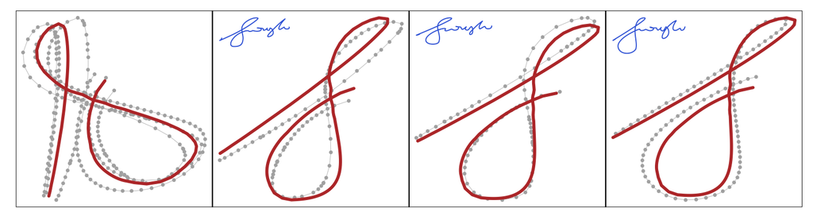

To know more about this problem, read Section 14.5.1 of [*Elements of Statistical Learning*](http://statweb.stanford.edu/~tibs/ElemStatLearn/printings/ESLII_print10.pdf) (ESL) or the [paper](http://www.jstor.org/stable/2345744) by Goodall.

“Procrustes was an African bandit in Greek mythology, who stretched or squashed his visitors to fit his iron bed (eventually killing them).”

[figure not shown]

1. Expand the Procrustes criterion, we obtain  
   $\begin{eqnarray*} & & \|\boldsymbol{X} - (\beta \boldsymbol{Y} \boldsymbol{O} + \boldsymbol{1}_n \boldsymbol{\mu}^T)\|_F^2 \\ &=& \text{tr}(\boldsymbol{X}^T \boldsymbol{X}) - 2 \text{tr}(\boldsymbol{X}^T(\beta \boldsymbol{Y} \boldsymbol{O} + \boldsymbol{1}_n \boldsymbol{\mu}^T)) + \text{tr}((\beta \boldsymbol{Y} \boldsymbol{O} + \boldsymbol{1}_n \boldsymbol{\mu}^T)^T(\beta \boldsymbol{Y} \boldsymbol{O} + \boldsymbol{1}_n \boldsymbol{\mu}^T)) \\ &=& \text{tr}(\boldsymbol{X}^T \boldsymbol{X}) + \beta^2 \text{tr}(\boldsymbol{Y}^T \boldsymbol{Y}) + n \boldsymbol{\mu}^T \boldsymbol{\mu} + 2 \beta \boldsymbol{\mu}^T \boldsymbol{O}^T \boldsymbol{Y}^T \boldsymbol{1}_n - 2 \beta \text{tr}(\boldsymbol{X}^T \boldsymbol{Y} \boldsymbol{O}) - 2 \boldsymbol{\mu}^T \boldsymbol{X}^T \boldsymbol{1}_n. \end{eqnarray*}$ Setting the partial derivatives with respect to $\boldsymbol{\mu}$ gives the stationarity condition $2n \boldsymbol{\mu} + 2 \beta \boldsymbol{O}^T \boldsymbol{Y}^T \boldsymbol{1}_n - 2 \boldsymbol{X}^T \boldsymbol{1}_n = \boldsymbol{0}_p,$ which implies that the optimal point satisfies $\boldsymbol{\mu} = n^{-1} \boldsymbol{X}^T \boldsymbol{1}_n - n^{-1} \beta \boldsymbol{O}^T \boldsymbol{Y}^T \boldsymbol{1}_n = \boldsymbol{\bar x} - \beta \boldsymbol{O}^T \boldsymbol{\bar y}.$ Substitution to the original criterion, we see $\|\boldsymbol{X} - (\beta \boldsymbol{Y} \boldsymbol{O} + \boldsymbol{1}_n \boldsymbol{\mu}^T)\|_F^2 = \|(\boldsymbol{X} - \boldsymbol{1} \boldsymbol{\bar x}^T) - \beta (\boldsymbol{Y} - \boldsymbol{1}_n \boldsymbol{\bar y}^T) \boldsymbol{O} \|_F^2 = \| \boldsymbol{\tilde X} - \beta \boldsymbol{\tilde Y} \boldsymbol{O}\|_F^2.$ Therefore we can always first (column) center both matrices and then do not need to consider shifting.
2. Writing $\| \boldsymbol{\tilde X} - \beta \boldsymbol{\tilde Y} \boldsymbol{O}\|_F^2 = \text{tr}(\boldsymbol{\tilde X}^T \boldsymbol{\tilde X}) - 2 \beta \text{tr}(\boldsymbol{O}^T \boldsymbol{\tilde Y}^T \boldsymbol{\tilde X}) + \beta^2 \text{tr}(\boldsymbol{\tilde Y}^T \boldsymbol{\tilde Y}),$ we need to maximize the term $\text{tr}(\boldsymbol{O}^T \boldsymbol{\tilde Y}^T \boldsymbol{\tilde X})$. Let the SVD of $\boldsymbol{\tilde Y}^T \boldsymbol{\tilde X}$ be $\boldsymbol{U} \boldsymbol{\Sigma} \boldsymbol{V}^T$. Then $\text{tr}(\boldsymbol{O}^T \boldsymbol{\tilde Y}^T \boldsymbol{\tilde X}) = \text{tr}(\boldsymbol{O}^T \boldsymbol{U} \boldsymbol{\Sigma} \boldsymbol{V}^T) = \text{tr}(\boldsymbol{V}^T \boldsymbol{O}^T \boldsymbol{U} \boldsymbol{\Sigma}) = \text{tr}(\boldsymbol{Z} \boldsymbol{\Sigma}) = \sum_i z_{ii} \sigma_i \le \sum_i \sigma_i,$ where $Z = \boldsymbol{V}^T \boldsymbol{O}^T \boldsymbol{U}$ is orthogonal and thus all its entries have magnitude $\le 1$. Taking $\boldsymbol{\hat O} = \boldsymbol{U} \boldsymbol{V}^T$ apparently achieves the maximum value $\sum_i \sigma_i = \text{tr}(\boldsymbol{\Sigma})$. Then optimal $\beta$ is $\hat \beta = \text{tr}(\boldsymbol{\Sigma}) / \|\boldsymbol{\tilde Y}\|_F^2$.
3. Above analysis suggests the optimal solution $\begin{eqnarray*} \boldsymbol{\hat O} &=& \boldsymbol{U} \boldsymbol{V}^T \\ \hat \beta &=& \text{tr}(\boldsymbol{\Sigma}) / \|\boldsymbol{\tilde Y}\|_F^2 \\ \boldsymbol{\hat \mu} &=& \boldsymbol{\bar x} - \hat \beta \boldsymbol{\hat O}^T \boldsymbol{\bar y}, \end{eqnarray*}$ which is straightforward to implement using SVD. We write a `procrustes` function for computing the optimal Procrustes rotation.

```r
#' Procurstes rotation for matching two matrices
#'
#' \code{procrustes} implements the Procrustes rotation method
#'
#' @param X an n-by-p matrix, the target shape
#' @param Y an n-by-p matrix, the shape to rotate
#' @return a list that contains:
#'  beta, a positive scaling factor
#'  O, a p-by-p orthogonal matrix
#'  mu, a p-by-1 vector of shift
#'  Z, the n-by-p resulting shape rotated from Y
#'  d, the Procrustes distance
#' @seealso
procrustes <- function(X, Y) {

  # check dimension
  if (dim(X)[1] != dim(Y)[1] || dim(X)[2] != dim(Y)[2])
    stop("X and Y should be matrices of same size")

  # center X and Y
  Xc <- scale(X, center = TRUE, scale = FALSE)
  Yc <- scale(Y, center = TRUE, scale = FALSE)

  # SVD of t(Yc) %*% Xc
  ytxsvd <- svd(crossprod(Yc, Xc))

  # collect results
  beta <- as.numeric(sum(ytxsvd$d) / norm(Yc, "F")^2)
  O <- tcrossprod(ytxsvd$u, ytxsvd$v)
  mu <- attr(Xc, "scaled:center") -
    beta * crossprod(O, attr(Yc, "scaled:center"))
  Z <- beta * (Y %*% O) + rep(mu, each = dim(X)[1])
  d <- norm(X - Z, "F")

  # output
  list(beta = beta, O = O, mu = mu, Z = Z, d = d)

  }
```

Let’s test run the function.

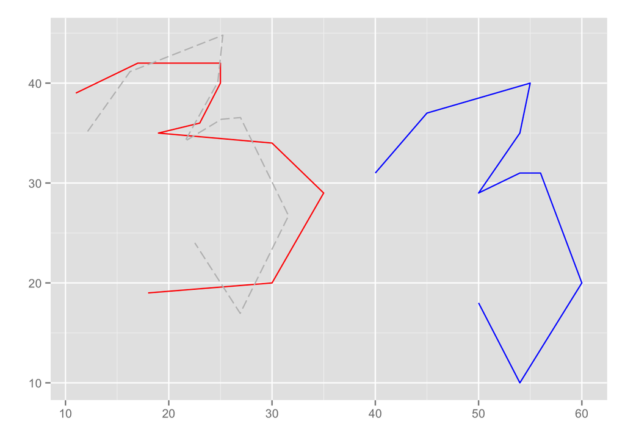

```r
library(ggplot2)
# read the two 3s data
X <- read.table("http://hua-zhou.github.io/teaching/st758-2014fall/X.txt",
                sep = ",")
X <- as.matrix(X)
Y <- read.table("http://hua-zhou.github.io/teaching/st758-2014fall/Y.txt",
                sep = ",")
Y <- as.matrix(Y)
# compute the Procrustes rotation
Z <- procrustes(X, Y)$Z
ggplot(data = data.frame(X, Y, Z)) +
  geom_path(aes(x = X[, 1], y = X[, 2]), colour = "red") +
  geom_path(aes(x = Y[, 1], y = Y[, 2]), colour = "blue") +
  geom_path(aes(x = Z[, 1], y = Z[, 2]), colour = "grey", linetype = 11) +
  xlab("") + ylab("")
```

Clean up workspace

```r
## clean and close
#rm(list = ls())
```